# Return Home

View Code on Github

# News Channels Youtube Data EDA

### 1 CNN

The Cable News Network is a multinational news channel and website headquartered in Atlanta

### 2.FOX

ommonly known as Fox News, is an American multinational conservative news and political commentary television channel and website based in New York City

### 3.Aljazeera

is a 24-hour English-language news channel. It operates under the ownership of the Al Jazeera Media Network, which, in turn, is funded by the government of Qatar.

### 4.BBC

s an operational business division[1] of the British Broadcasting Corporation (BBC) responsible for the gathering and broadcasting of news and current affairs in the UK and around the world.

### 5.NBC

is the news division of the American broadcast television network NBC. The division operates under NBCUniversal Television and Streaming, a division of NBCUniversal, which is, in turn, a wholly owned subsidiary of Comcast.

### 6 ABC

s the news division of the American television network ABC. Its flagship program is the daily evening newscast ABC World News Tonight with David Muir; other programs include morning news-talk show Good Morning America, Nightline, Primetime, 20/20, and Sunday morning political affairs program This Week with George Stephanopoulos.

```python
pip install google-api-python-client
```

```python
# lets import libraries
from googleapiclient.discovery import build
import pandas as pd
import seaborn as sns
```

# 1 CNN Channel Stats

## Function to get CNN channel statistics

```python
api_key = 'AIzaSyB24Kop04L1GlTgRCm1XtQ4KB2a4gaBOwA'
cnn_channel_id = ['UCupvZG-5ko_eiXAupbDfxWw' # CNN

              ]
youtube = build('youtube','v3',developerKey = api_key)

from googleapiclient.errors import HttpError

def get_channel_stats(youtube, cnn_channel_id):
    all_data = []
    try:
        request = youtube.channels().list(
            part='snippet,contentDetails,statistics',
            id=','.join(cnn_channel_id)
        )
        response = request.execute()

        for item in response.get('items', []):
            snippet = item.get('snippet', {})
            statistics = item.get('statistics', {})

            data = {
                'Channel_name': snippet.get('title', ''),
                'Subscribers': statistics.get('subscriberCount', ''),
                'Views': statistics.get('viewCount', ''),
                'Total_videos': statistics.get('videoCount', '')
            }

            all_data.append(data)

    except HttpError as e:
        print(f"HTTP error occurred: {e}")
        print(f"Request URL: {e.resp.request.url}")
        print(f"Request body: {e.resp.request.body}")

    return all_data
```

```python
get_channel_stats(youtube, cnn_channel_id)
```

```
[{'Channel_name': 'CNN',
  'Subscribers': '16000000',
  'Views': '15240048075',
  'Total_videos': '163094'}]
```

```python
channel_statistics = get_channel_stats(youtube, channel_id)
```

```python
cnn_channel_data =pd.DataFrame(channel_statistics)
```

```python
cnn_channel_data
```

|  | Channel_name | Subscribers | Views | Total_videos |
| --- | --- | --- | --- | --- |
| 0 | CNN | 16000000 | 15240048075 | 163094 |

# 2 Fox Channel Stats

```python
api_key = 'AIzaSyB24Kop04L1GlTgRCm1XtQ4KB2a4gaBOwA'
fox_channel_id = ['UCXIJgqnII2ZOINSWNOGFThA' # FOX News

              ]
youtube = build('youtube','v3',developerKey = api_key)
```

## Function to get FOX channel statistics

```python
from googleapiclient.errors import HttpError

def get_channel_stats(youtube, fox_channel_id):
    all_data = []
    try:
        request = youtube.channels().list(
            part='snippet,contentDetails,statistics',
            id=','.join(fox_channel_id)
        )
        response = request.execute()

        for item in response.get('items', []):
            snippet = item.get('snippet', {})
            statistics = item.get('statistics', {})

            data = {
                'Channel_name': snippet.get('title', ''),
                'Subscribers': statistics.get('subscriberCount', ''),
                'Views': statistics.get('viewCount', ''),
                'Total_videos': statistics.get('videoCount', '')
            }

            all_data.append(data)

    except HttpError as e:
        print(f"HTTP error occurred: {e}")
        print(f"Request URL: {e.resp.request.url}")
        print(f"Request body: {e.resp.request.body}")

    return all_data
```

```python
get_channel_stats(youtube, fox_channel_id)
```

```
[{'Channel_name': 'Fox News',
  'Subscribers': '11000000',
  'Views': '15999126832',
  'Total_videos': '101095'}]
```

```python
fox_news_channel_statistics = get_channel_stats(youtube, fox_channel_id)
```

```python
fox_news_channel_data =pd.DataFrame(fox_news_channel_statistics)
```

```python
fox_news_channel_data
```

|  | Channel_name | Subscribers | Views | Total_videos |
| --- | --- | --- | --- | --- |
| 0 | Fox News | 11000000 | 15999126832 | 101095 |

# 3 Aljazeera English Channel Stats

## Functions to get Aljazeera channel statistics

```python
api_key = 'AIzaSyB24Kop04L1GlTgRCm1XtQ4KB2a4gaBOwA'
alajazeera_english_channel_id = ['UCNye-wNBqNL5ZzHSJj3l8Bg'  # Aljazeera English

              ]
youtube = build('youtube','v3',developerKey = api_key)



from googleapiclient.errors import HttpError

def get_channel_stats(youtube, alajazeera_english_channel_id ):
    all_data = []
    try:
        request = youtube.channels().list(
            part='snippet,contentDetails,statistics',
            id=','.join(alajazeera_english_channel_id )
        )
        response = request.execute()

        for item in response.get('items', []):
            snippet = item.get('snippet', {})
            statistics = item.get('statistics', {})

            data = {
                'Channel_name': snippet.get('title', ''),
                'Subscribers': statistics.get('subscriberCount', ''),
                'Views': statistics.get('viewCount', ''),
                'Total_videos': statistics.get('videoCount', '')
            }

            all_data.append(data)

    except HttpError as e:
        print(f"HTTP error occurred: {e}")
        print(f"Request URL: {e.resp.request.url}")
        print(f"Request body: {e.resp.request.body}")

    return all_data
```

```python
get_channel_stats(youtube, alajazeera_english_channel_id )
```

```
[{'Channel_name': 'Al Jazeera English',
  'Subscribers': '12700000',
  'Views': '4088036694',
  'Total_videos': '110679'}]
```

```python
alajazeera_channel_statistics = get_channel_stats(youtube, alajazeera_english_channel_id)
```

```python
aljazeera_channel_data =pd.DataFrame(alajazeera_channel_statistics)
```

```python
aljazeera_channel_data
```

|  | Channel_name | Subscribers | Views | Total_videos |
| --- | --- | --- | --- | --- |
| 0 | Al Jazeera English | 12700000 | 4088036694 | 110679 |

# 4 BBC News Channel Stats

## Functions to get BBC News Channel statistics

```python
api_key = 'AIzaSyB24Kop04L1GlTgRCm1XtQ4KB2a4gaBOwA'
bbc_news_english_channel_id = [ 'UCQXHTFnQYFTqN0MqmNh9EIA' # BBC World Service

              ]
youtube = build('youtube','v3',developerKey = api_key)



from googleapiclient.errors import HttpError

def get_channel_stats(youtube, bbc_news_english_channel_id ):
    all_data = []
    try:
        request = youtube.channels().list(
            part='snippet,contentDetails,statistics',
            id=','.join(bbc_news_english_channel_id)
        )
        response = request.execute()

        for item in response.get('items', []):
            snippet = item.get('snippet', {})
            statistics = item.get('statistics', {})

            data = {
                'Channel_name': snippet.get('title', ''),
                'Subscribers': statistics.get('subscriberCount', ''),
                'Views': statistics.get('viewCount', ''),
                'Total_videos': statistics.get('videoCount', '')
            }

            all_data.append(data)

    except HttpError as e:
        print(f"HTTP error occurred: {e}")
        print(f"Request URL: {e.resp.request.url}")
        print(f"Request body: {e.resp.request.body}")

    return all_data
```

```python
get_channel_stats(youtube, bbc_news_english_channel_id )
```

```
[{'Channel_name': 'BBC World Service',
  'Subscribers': '378000',
  'Views': '44415527',
  'Total_videos': '965'}]
```

```python
bbc_news_channel_statistics = get_channel_stats(youtube, bbc_news_english_channel_id)
```

```python
bbc_news_channel_data =pd.DataFrame(bbc_news_channel_statistics)
```

```python
bbc_news_channel_data
```

|  | Channel_name | Subscribers | Views | Total_videos |
| --- | --- | --- | --- | --- |
| 0 | BBC World Service | 378000 | 44415527 | 965 |

# 5 NBC News Channel Stats

## Functions to get NBC News channel statistics

```python
api_key = 'AIzaSyB24Kop04L1GlTgRCm1XtQ4KB2a4gaBOwA'
nbc_news_channel_id = [ 'UCeY0bbntWzzVIaj2z3QigXg'  # NBC News

              ]
youtube = build('youtube','v3',developerKey = api_key)



from googleapiclient.errors import HttpError

def get_channel_stats(youtube, nbc_news_channel_id):
    all_data = []
    try:
        request = youtube.channels().list(
            part='snippet,contentDetails,statistics',
            id=','.join(nbc_news_channel_id)
        )
        response = request.execute()

        for item in response.get('items', []):
            snippet = item.get('snippet', {})
            statistics = item.get('statistics', {})

            data = {
                'Channel_name': snippet.get('title', ''),
                'Subscribers': statistics.get('subscriberCount', ''),
                'Views': statistics.get('viewCount', ''),
                'Total_videos': statistics.get('videoCount', '')
            }

            all_data.append(data)

    except HttpError as e:
        print(f"HTTP error occurred: {e}")
        print(f"Request URL: {e.resp.request.url}")
        print(f"Request body: {e.resp.request.body}")

    return all_data
```

```python
get_channel_stats(youtube, nbc_news_channel_id )
```

```
[{'Channel_name': 'NBC News',
  'Subscribers': '9580000',
  'Views': '6857221109',
  'Total_videos': '60314'}]
```

```python
nbc_news_channel_statistics = get_channel_stats(youtube,nbc_news_channel_id)
```

```python
nbc_news_channel_data =pd.DataFrame(nbc_news_channel_statistics)
```

```python
nbc_news_channel_data
```

|  | Channel_name | Subscribers | Views | Total_videos |
| --- | --- | --- | --- | --- |
| 0 | NBC News | 9580000 | 6857221109 | 60314 |

# 6 ABC News Channel Stats

```python
api_key = 'AIzaSyB24Kop04L1GlTgRCm1XtQ4KB2a4gaBOwA'
abc_news_channel_id = [ 'UCBi2mrWuNuyYy4gbM6fU18Q'  # ABC News

              ]
youtube = build('youtube','v3',developerKey = api_key)



from googleapiclient.errors import HttpError

def get_channel_stats(youtube, abc_news_channel_id ):
    all_data = []
    try:
        request = youtube.channels().list(
            part='snippet,contentDetails,statistics',
            id=','.join(abc_news_channel_id)
        )
        response = request.execute()

        for item in response.get('items', []):
            snippet = item.get('snippet', {})
            statistics = item.get('statistics', {})

            data = {
                'Channel_name': snippet.get('title', ''),
                'Subscribers': statistics.get('subscriberCount', ''),
                'Views': statistics.get('viewCount', ''),
                'Total_videos': statistics.get('videoCount', '')
            }

            all_data.append(data)

    except HttpError as e:
        print(f"HTTP error occurred: {e}")
        print(f"Request URL: {e.resp.request.url}")
        print(f"Request body: {e.resp.request.body}")

    return all_data
```

```python
get_channel_stats(youtube, abc_news_channel_id )
```

```
[{'Channel_name': 'ABC News',
  'Subscribers': '15700000',
  'Views': '13971514055',
  'Total_videos': '85577'}]
```

```python
abc_news_channel_statistics = get_channel_stats(youtube, abc_news_channel_id)
```

```python
abc_news_channel_data =pd.DataFrame(abc_news_channel_statistics)
```

```python
abc_news_channel_data
```

|  | Channel_name | Subscribers | Views | Total_videos |
| --- | --- | --- | --- | --- |
| 0 | ABC News | 15700000 | 13971514055 | 85577 |

```python
# Lets combine the data frames

cnn_channel_data
fox_news_channel_data
aljazeera_channel_data
bbc_news_channel_data
nbc_news_channel_data
abc_news_channel_data
# Combine DataFrames using concat
combined_news_channels_df = pd.concat([cnn_channel_data ,
                                       fox_news_channel_data ,
                                       bbc_news_channel_data ,
                                       nbc_news_channel_data,
                                      abc_news_channel_data

                                      ], ignore_index=True)

# Display the result
print(combined_news_channels_df)
```

```
        Channel_name Subscribers        Views Total_videos
0                CNN    16000000  15240048075       163094
1           Fox News    11000000  15999126832       101095
2  BBC World Service      378000     44415527          965
3           NBC News     9580000   6857221109        60314
4           ABC News    15700000  13971514055        85577
```

```python
# lets have  a look at the datatypes
combined_news_channels_df.info()
```

```
<class 'pandas.core.frame.DataFrame'>
RangeIndex: 5 entries, 0 to 4
Data columns (total 4 columns):
 #   Column        Non-Null Count  Dtype
---  ------        --------------  -----
 0   Channel_name  5 non-null      object
 1   Subscribers   5 non-null      object
 2   Views         5 non-null      object
 3   Total_videos  5 non-null      object
dtypes: object(4)
memory usage: 292.0+ bytes
```

```python
# lets change the datatypes to perform  visualisations
combined_news_channels_df['Subscribers'] = pd.to_numeric(combined_news_channels_df['Subscribers'])
combined_news_channels_df['Views'] = pd.to_numeric(combined_news_channels_df['Views'])
combined_news_channels_df['Total_videos'] = pd.to_numeric(combined_news_channels_df['Total_videos'])
# letsconirm if the datatypes has changed
combined_news_channels_df.info()
```

```
<class 'pandas.core.frame.DataFrame'>
RangeIndex: 5 entries, 0 to 4
Data columns (total 4 columns):
 #   Column        Non-Null Count  Dtype
---  ------        --------------  -----
 0   Channel_name  5 non-null      object
 1   Subscribers   5 non-null      int64
 2   Views         5 non-null      int64
 3   Total_videos  5 non-null      int64
dtypes: int64(3), object(1)
memory usage: 292.0+ bytes
```

```python
combined_news_channels_df
```

|  | Channel_name | Subscribers | Views | Total_videos |
| --- | --- | --- | --- | --- |
| 0 | CNN | 16000000 | 15240048075 | 163094 |
| 1 | Fox News | 11000000 | 15999126832 | 101095 |
| 2 | BBC World Service | 378000 | 44415527 | 965 |
| 3 | NBC News | 9580000 | 6857221109 | 60314 |
| 4 | ABC News | 15700000 | 13971514055 | 85577 |

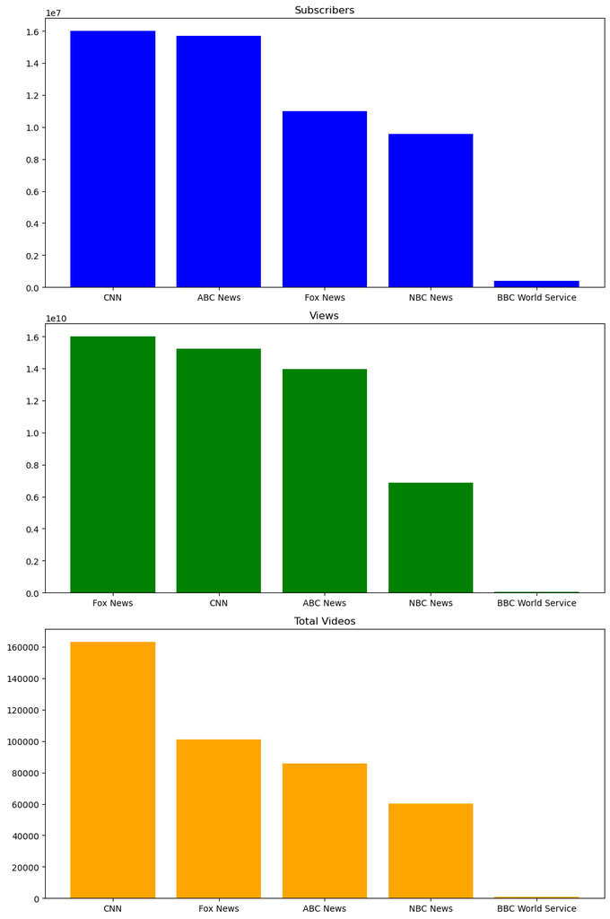

```python
import matplotlib.pyplot as plt

# Sort the DataFrame by 'Subscribers' in descending order
combined_news_channels_df_subscribers_sorted = combined_news_channels_df.sort_values(by='Subscribers', ascending=False)

# Plotting Subscribers in descending order
fig, axes = plt.subplots(nrows=3, ncols=1, figsize=(10, 15))

axes[0].bar(combined_news_channels_df_subscribers_sorted['Channel_name'], combined_news_channels_df_subscribers_sorted['Subscribers'], color='blue')
axes[0].set_title('Subscribers')

# Sort the DataFrame by 'Views' in descending order
combined_news_channels_df_views_sorted = combined_news_channels_df.sort_values(by='Views', ascending=False)

# Plotting Views in descending order
axes[1].bar(combined_news_channels_df_views_sorted['Channel_name'], combined_news_channels_df_views_sorted['Views'], color='green')
axes[1].set_title('Views')

# Sort the DataFrame by 'Total_videos' in descending order
combined_news_channels_df_total_videos_sorted = combined_news_channels_df.sort_values(by='Total_videos', ascending=False)

# Plotting Total Videos in descending order
axes[2].bar(combined_news_channels_df_total_videos_sorted['Channel_name'], combined_news_channels_df_total_videos_sorted['Total_videos'], color='orange')
axes[2].set_title('Total Videos')

# Adjust layout for better visibility
plt.tight_layout()

# Show the plot
plt.show()
```